# Lecture 7: Descriptive statistics and exploratory analysis

ØKA2015 Applied Data Science, University of Inland Norway

Touseef Hameed

6 October 2026

# 1 What this document is

This is Lecture 7 as a written tutorial, in the same order as the script `lecture07_descriptive.R` and as Chapter 2 of *Business Analytics* (Camm et al.). Read it after the lecture, or run it: open the `.Rmd` file in RStudio, press **Knit**, and this PDF is rebuilt on your computer.

In Lectures 3 to 6 you brought data into R and changed it. Today you describe it with numbers: what kind of data it is, where its centre is, how spread out it is, which values are unusual, and how two variables move together.

# 2 Packages and the data

Three packages. Install each once per computer; running the install again does no harm.

```r
install.packages("tidyverse")
install.packages("nycflights13")
install.packages("GGally")
```

Load them every session:

```r
library(tidyverse)
library(nycflights13)
library(GGally)
flights <- nycflights13::flights
weather <- nycflights13::weather
```

`flights` is the table from Lectures 4 to 6. `weather` has one row per hour at the three New York airports in 2013: temperature, humidity, wind, pressure and visibility.

# 3 Types of data

## 3.1 Population and sample

The **population** is every element of interest. A **sample** is a subset of it. Here the population is all 2013 flights from New York. `slice_sample()` draws a random sample, and `set.seed()` fixes the random draw so that everyone gets the same sample.

```r
set.seed(2026)
flights_sample <- flights |>
  slice_sample(n = 1000)
mean(flights$dep_delay, na.rm = TRUE)
```

```
#> [1] 12.63907
```

```r
mean(flights_sample$dep_delay, na.rm = TRUE)
```

```
#> [1] 12.89673
```

The sample mean, 12.9 minutes, is close to the population mean, 12.6. A random sample is representative: on average it tells the truth about the population. In practice we nearly always work with samples.

## 3.2 Quantitative and categorical

A **quantitative** variable is a number you can add and average: `<int>` or `<dbl>` in R. It is *discrete* if it counts (month, flights per day) and *continuous* if it measures (distance, air time). A **categorical** variable is a label you can only count: `<chr>` or `<fct>`. It is *nominal* if the categories have no order (carrier, origin) and *ordinal* if they do (low, medium, high).

```r
flights |>
  select(carrier, month, dep_delay) |>
  glimpse()
```

```
#> Rows: 336,776
#> Columns: 3
#> $ carrier   <chr> "UA", "UA", "AA", "B6", "DL", "UA", "B6", "EV", "B6", "AA", …
#> $ month     <int> 1, 1, 1, 1, 1, 1, 1, 1, 1, 1, 1, 1, 1, 1, 1, 1, 1, 1, 1, 1, …
#> $ dep_delay <dbl> 2, 4, 2, -1, -6, -4, -5, -3, -3, -2, -2, -2, -2, -2, -1, 0, …
```

Careful: a number can be a label. A postcode or a 1 to 5 rating is categorical, even if R stores it as a number.

## 3.3 Cross-sectional and time series

**Cross-sectional** data describe many units at about the same point in time. A **time series** measures one quantity over many time periods.

```r
flights |> filter(month == 1, day == 1) |> nrow()
```

```
#> [1] 842
```

```r
flights |> count(month)
```

```
#> # A tibble: 12 × 2
#>   month     n
#>   <int> <int>
#> 1     1 27004
#> 2     2 24951
#> 3     3 28834
#> 4     4 28330
#> 5     5 28796
#> # ℹ 7 more rows
```

The 842 flights of 1 January are a cross-section. The number of flights per month is a time series.

# 4 Distributions

**Descriptive analysis** summarises what is in the data. **Exploratory analysis** looks for patterns and relationships you did not know about. Exploration suggests questions; it does not prove answers. Correlation is not causation.

A **distribution** shows which values a variable takes, and how often.

## 4.1 A categorical variable: a frequency table

```r
flights |>
  count(carrier, sort = TRUE) |>
  mutate(percent = round(100 * n / sum(n), 1))
```

```
#> # A tibble: 16 × 3
#>   carrier     n percent
#>   <chr>   <int>   <dbl>
#> 1 UA      58665    17.4
#> 2 B6      54635    16.2
#> 3 EV      54173    16.1
#> 4 DL      48110    14.3
#> 5 AA      32729     9.7
#> # ℹ 11 more rows
```

`n` is the frequency; `percent` is the percent frequency. United flew 17.4% of the flights.

## 4.2 A quantitative variable: a histogram

A histogram splits the range into bins and draws one bar per bin. `breaks` sets the number of bins and `xlim` the part of the x-axis shown.

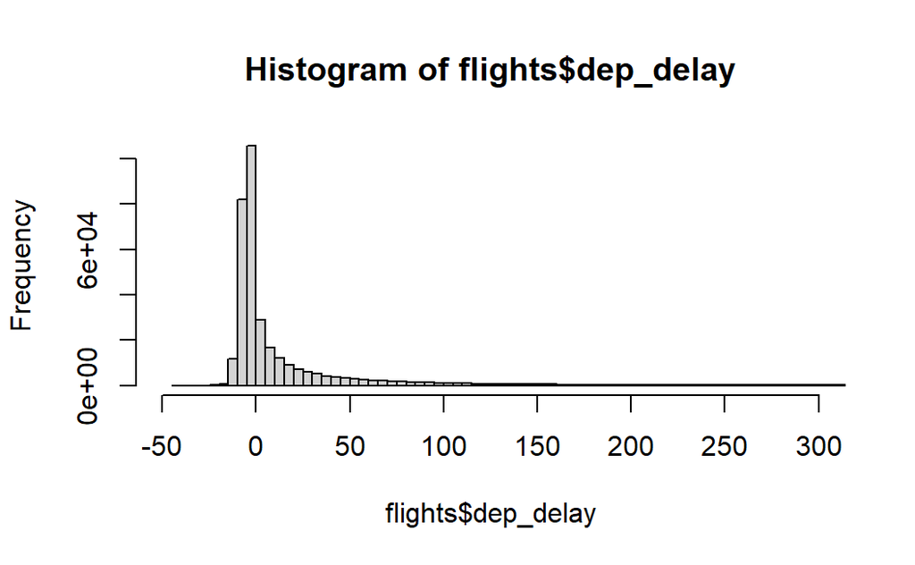

```r
hist(flights$dep_delay, breaks = 200, xlim = c(-50, 300))
```

## 4.3 The shape of a distribution

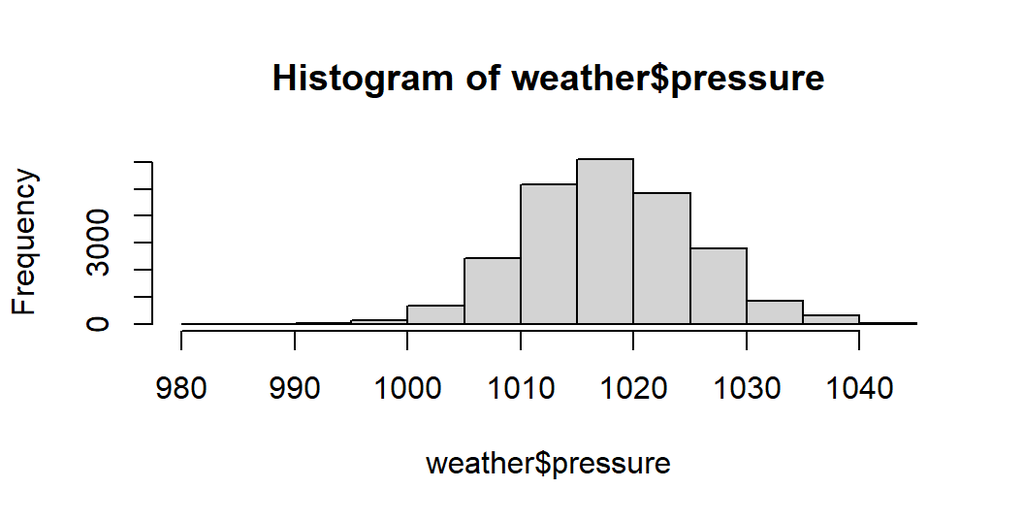

```r
hist(weather$pressure)
```

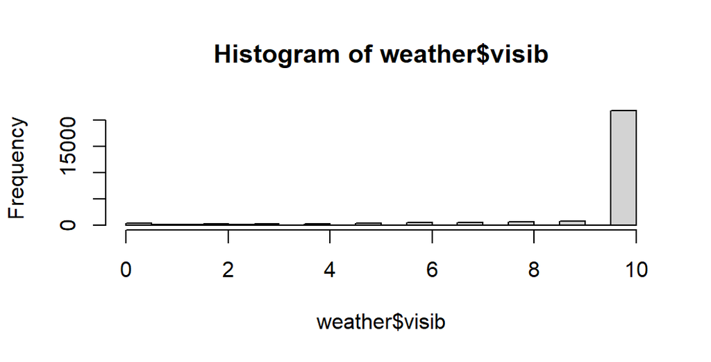

```r
hist(weather$visib)
```

Pressure is **symmetric**: the left side mirrors the right, and the mean (1017.9) is close to the median (1017.6). Departure delay is **skewed right**: a long tail to the right, and the mean (12.6) is above the median (-2). Visibility is **skewed left**: a long tail to the left, and the mean (9.3) is below the median (10).

# 5 Central tendency

## 5.1 Mean, median, mode

The **mean** is the sum divided by the count. The **median** is the middle value once the values are sorted. The **mode** is the most frequent value. R has no function for the mode, but `count(sort = TRUE)` puts it on top.

```r
books <- c(3, 7, 2, 9, 7, 5, 7)
mean(books)
```

```
#> [1] 5.714286
```

```r
median(books)
```

```
#> [1] 7
```

```r
tibble(books) |> count(books, sort = TRUE)
```

```
#> # A tibble: 5 × 2
#>   books     n
#>   <dbl> <int>
#> 1     7     3
#> 2     2     1
#> 3     3     1
#> 4     5     1
#> 5     9     1
```

## 5.2 Mean or median?

```r
mean(flights$dep_delay, na.rm = TRUE)
```

```
#> [1] 12.63907
```

```r
median(flights$dep_delay, na.rm = TRUE)
```

```
#> [1] -2
```

```r
flights |> count(dep_delay, sort = TRUE)
```

```
#> # A tibble: 528 × 2
#>   dep_delay     n
#>       <dbl> <int>
#> 1        -5 24821
#> 2        -4 24619
#> 3        -3 24218
#> 4        -2 21516
#> 5        -6 20701
#> # ℹ 523 more rows
```

The mean uses every value, so a few very late flights pull it up to 12.6 minutes. The median uses only the order: the typical flight left two minutes early. For skewed data, report the median, or both.

## 5.3 The centre for each group

```r
flights |>
  group_by(origin) |>
  summarise(
    mean   = mean(dep_delay, na.rm = TRUE),
    median = median(dep_delay, na.rm = TRUE),
    n      = n())
```

```
#> # A tibble: 3 × 4
#>   origin   mean median      n
#>   <chr>   <dbl>  <dbl>  <int>
#> 1 EWR    15.108     -1 120835
#> 2 JFK    12.112     -1 111279
#> 3 LGA    10.347     -3 104662
```

Newark has the highest mean delay. All three medians are below zero. Always report `n` beside an average.

## 5.4 Filling a missing value

The shape decides which value to fill with: the mean for a symmetric quantitative variable, the median for a skewed one or one with outliers, the mode for a categorical one.

```r
weather_filled <- weather |>
  mutate(pressure = replace_na(pressure, mean(pressure, na.rm = TRUE)))
sum(is.na(weather$pressure))
```

```
#> [1] 2729
```

```r
sum(is.na(weather_filled$pressure))
```

```
#> [1] 0
```

```r
flights |> count(carrier, sort = TRUE) |> slice(1)
```

```
#> # A tibble: 1 × 2
#>   carrier     n
#>   <chr>   <int>
#> 1 UA      58665
```

Filling changes the data. Do it only with a reason, and say so in your report.

# 6 Variability

## 6.1 Variance and standard deviation

The **variance** is the average squared distance from the mean, dividing by $n - 1$ for a sample. The **standard deviation** is its square root, back in the units of the data.

```r
scores <- c(70, 75, 80, 85, 90)
tibble(scores) |>
  mutate(deviation = scores - mean(scores),
         squared   = deviation^2)
```

```
#> # A tibble: 5 × 3
#>   scores deviation squared
#>    <dbl>     <dbl>   <dbl>
#> 1     70       -10     100
#> 2     75        -5      25
#> 3     80         0       0
#> 4     85         5      25
#> 5     90        10     100
```

```r
var(scores)
```

```
#> [1] 62.5
```

```r
sd(scores)
```

```
#> [1] 7.905694
```

The squared deviations sum to 250, so the variance is 250 / 4 = 62.5 and the standard deviation is 7.9 points. We report the standard deviation because it is in the units of the data.

## 6.2 Spread on real data

```r
sd(flights$dep_delay, na.rm = TRUE)
```

```
#> [1] 40.21006
```

```r
range(flights$dep_delay, na.rm = TRUE)
```

```
#> [1]  -43 1301
```

```r
quantile(flights$dep_delay, c(0.25, 0.50, 0.75), na.rm = TRUE)
```

```
#> 25% 50% 75%
#>  -5  -2  11
```

```r
IQR(flights$dep_delay, na.rm = TRUE)
```

```
#> [1] 16
```

```r
summary(flights$dep_delay)
```

```
#>    Min. 1st Qu.  Median    Mean 3rd Qu.    Max.    NA's
#>  -43.00   -5.00   -2.00   12.64   11.00 1301.00    8255
```

The **range** uses only the two extreme values. The *p*th **percentile** has *p*% of the values below it. The **quartiles** are the 25th, 50th and 75th percentiles. The **IQR**, Q3 minus Q1, is the spread of the middle 50%: here 16 minutes. Extreme values do not move it. The **coefficient of variation**, sd divided by the mean, gives the spread relative to the mean, without units.

# 7 Outliers

An **outlier** is an observation far from the others. It can be an error or a real but rare case. Find it, check where it comes from, then decide. A confirmed error is corrected or removed, and you write down what you did. A real value is kept, and you use measures it does not distort, such as the median and the IQR.

## 7.1 The IQR rule and the boxplot

Values below Q1 - 1.5 IQR or above Q3 + 1.5 IQR are flagged. For departure delay the fences are -5 - 24 = -29 and 11 + 24 = 35.

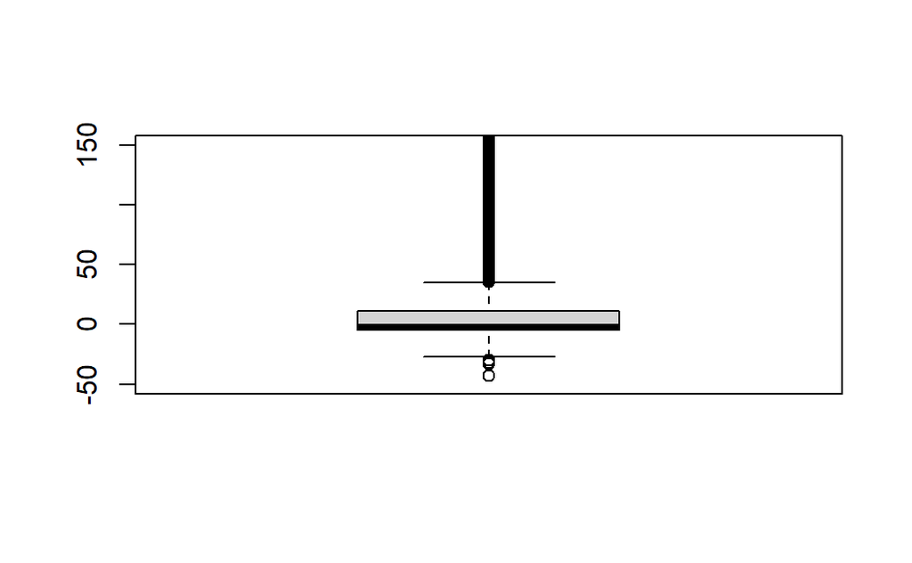

```r
boxplot(flights$dep_delay, ylim = c(-50, 150))
```

```r
flights |>
  filter(dep_delay < -29 | dep_delay > 35) |>
  nrow()
```

```
#> [1] 43216
```

The box runs from Q1 to Q3, the thick line is the median, and the dots are flagged values. In skewed data the rule flags many real values: 43,216 flights here. A flag is not a verdict.

## 7.2 The z-score rule

A z-score is how many standard deviations a value lies from the mean: $z = (x - \bar{x}) / s$. For a bell-shaped distribution about 68% of values lie within 1 sd, 95% within 2 and nearly all within 3, so $|z| > 3$ is rare and worth a look.

```r
m <- mean(flights$dep_delay, na.rm = TRUE)
s <- sd(flights$dep_delay, na.rm = TRUE)
flights |>
  mutate(z = (dep_delay - m) / s) |>
  filter(abs(z) > 3) |>
  nrow()
```

```
#> [1] 7928
```

The z-score rule works best for symmetric data. For skewed data, prefer the IQR rule.

## 7.3 A real data entry error

```r
weather |>
  arrange(desc(wind_speed)) |>
  select(origin, month, day, hour, wind_speed)
```

```
#> # A tibble: 26,115 × 5
#>   origin month   day  hour wind_speed
#>   <chr>  <int> <int> <int>      <dbl>
#> 1 EWR        2    12     3   1048.4
#> 2 EWR        1    31     6     42.579
#> 3 JFK        1    31     4     42.579
#> 4 EWR        1    31     4     40.277
#> 5 LGA        1    31     4     40.277
#> # ℹ 26,110 more rows
```

A hurricane is about 75 mph, so 1,048 mph is a recording error. Remove it, and write down that you did:

```r
weather_clean <- weather |>
  filter(wind_speed < 200 | is.na(wind_speed))
nrow(weather) - nrow(weather_clean)
```

```
#> [1] 1
```

The longest departure delay, 1,301 minutes on 9 January, is a real flight. Keep it.

# 8 Association between two variables

## 8.1 Scatter plots

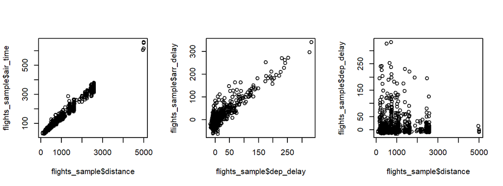

```r
par(mfrow = c(1, 3))
plot(flights_sample$distance, flights_sample$air_time)
plot(flights_sample$dep_delay, flights_sample$arr_delay)
plot(flights_sample$distance, flights_sample$dep_delay)
```

Longer flights take longer: a tight upward line. Late departures arrive late: upward. Distance says nothing about delay: no pattern. (`par(mfrow = c(1, 3))` puts the three plots side by side in this document; in RStudio you can run the three `plot()` lines one at a time.)

## 8.2 Covariance and correlation

```r
cov(flights$distance, flights$air_time, use = "complete.obs")
```

```
#> [1] 68301.35
```

```r
cor(flights$distance, flights$air_time, use = "complete.obs")
```

```
#> [1] 0.9906496
```

```r
cor(flights$dep_delay, flights$arr_delay, use = "complete.obs")
```

```
#> [1] 0.9148028
```

```r
cor(flights$distance, flights$dep_delay, use = "complete.obs")
```

```
#> [1] -0.02167079
```

**Covariance** is positive when two variables move together and negative when they move apart, but its size depends on the units. **Correlation** rescales it to lie between -1 and +1, with no units: +1 is a perfect positive relationship, 0 no linear relationship, -1 a perfect negative one. `use = "complete.obs"` skips rows with a missing value.

## 8.3 Many pairs at once

```r
flights |>
  select(dep_delay, arr_delay, air_time, distance) |>
  cor(use = "complete.obs") |>
  round(2)
```

```
#>           dep_delay arr_delay air_time distance
#> dep_delay      1.00      0.91    -0.02    -0.02
#> arr_delay      0.91      1.00    -0.04    -0.06
#> air_time      -0.02     -0.04     1.00     0.99
#> distance      -0.02     -0.06     0.99     1.00
```

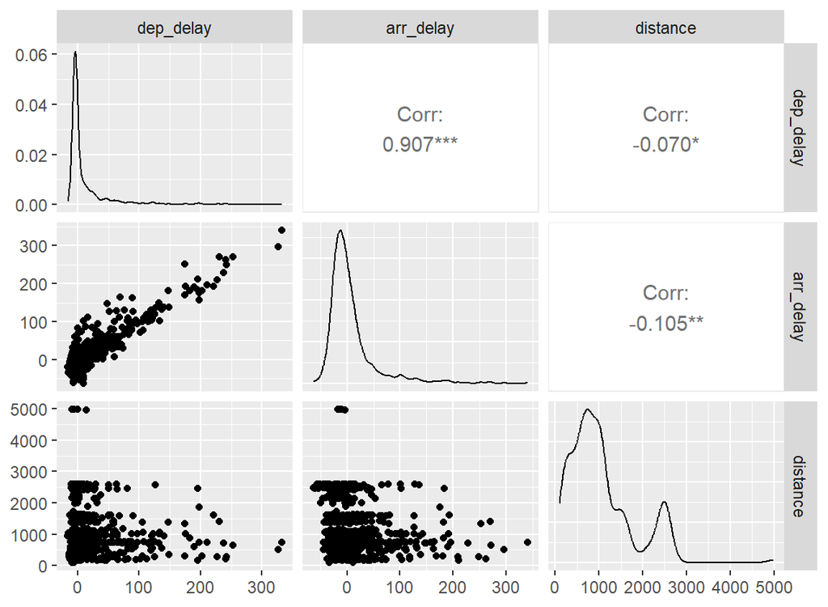

```r
flights_sample |>
  select(dep_delay, arr_delay, distance) |>
  ggpairs()
```

Correlation is not causation. Late departures and late arrivals move together ($r = 0.91$), but these numbers alone cannot say why.

# 9 What you can do now

- name the type of a variable and of a dataset
- describe a distribution: frequency table, histogram, shape
- report the centre (mean, median, mode) and the spread (sd, IQR)
- flag outliers with the IQR rule and z-scores, and decide what to do
- describe two variables together with a scatter plot and a correlation

# 10 Sources

- Camm, J. D., Fry, M. J., Cochran, J. J. and Ohlmann, J. W. (2024). *Business Analytics*. Cengage. Ch. 2, Descriptive Statistics.
- Wright, C., Ellis, S., Hicks, S. and Peng, R. (2021). *Tidyverse Skills for Data Science in R*, Ch. 5.4 and 5.5. https://jhudatascience.org/tidyversecourse/
- Course repository: https://github.com/touseefhameed/oka2015-applied-data-science